# Probability Distributions, Precision, Repeatability, Reproducibility (Stability), and Comparisons

## Plot of the Day-to-Day Variability over 90 days

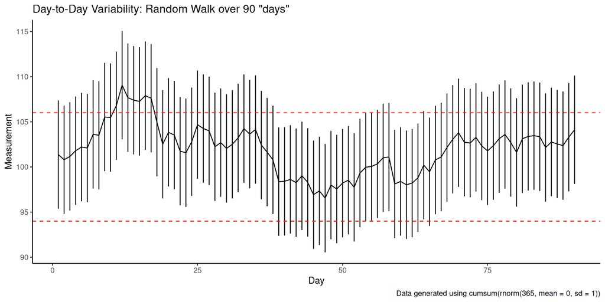

```r
day_to_day_1000 |>
  filter(day <= 90) |>
  ggplot(aes(x = day, y = measurement)) +
  geom_line() +
  geom_errorbar(aes(ymin = measurement - 6, ymax = measurement + 6), width = 0.0) +
  geom_hline(yintercept = c(94, 106), color = "red", linetype = "dashed") +
  labs(
    x = "Day",
    y = "Measurement",
    title = "Day-to-Day Variability: Random Walk over 90 \"days\"",
    caption = "Data generated using cumsum(rnorm(365, mean = 0, sd = 1))"
  ) +
  theme_classic()
```

## Plot of the Day-to-Day Variability over 3 runs during 90 days

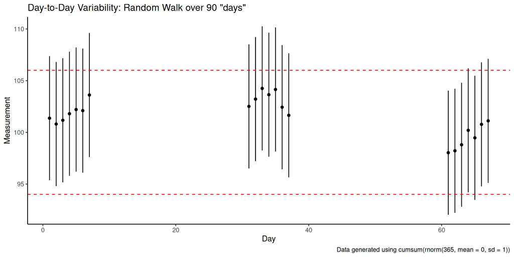

```r
days_to_keep <- c(1:7, 31:37, 61:67)

day_to_day_1000 |>
  filter(day %in% days_to_keep) |>
  ggplot(aes(x = day, y = measurement)) +
  geom_point() +
  geom_errorbar(aes(ymin = measurement - 6, ymax = measurement + 6), width = 0.0) +
  geom_hline(yintercept = c(94, 106), color = "red", linetype = "dashed") +
  labs(
    x = "Day",
    y = "Measurement",
    title = "Day-to-Day Variability: Random Walk over 90 \"days\"",
    caption = "Data generated using cumsum(rnorm(365, mean = 0, sd = 1))"
  ) +
  theme_classic()
```

## Level-3 Standard Deviation Calculation

```r
days_to_keep <- c(1:7, 31:37, 61:67)

day_to_day_1000 |>
  filter(day %in% days_to_keep) |>
  mutate(run_id = case_when(
    day <= 7 ~ "Run 1",
    day > 30 & day <= 37 ~ "Run 2",
    TRUE ~ "Run 3")
  ) |>
  group_by(run_id) |>
  summarise(mean_measurement = mean(measurement)) |>
  summarise(count = n(), sd_measurement = sd(mean_measurement))
```

| count | sd_measurement |
| --- | --- |
| 3 | 1.830826 |

# Comparisons

## Methods for Comparisons

### Statistical Tests (Hypothesis Testing)

- Provide a methodology for making quantitative decisions about a process or processes
- Rigorous theory
- Assumptions must be met
- Significance levels are often confused for practical significance

### Confidence Intervals

- Provide a range of values that are likely to contain the true value
- The confidence level is set as $1 - \alpha$
- Assumptions must be met
- Care needed to ensure the propper test is used.

## Statistical Test (Hypothesis Testing)

$$\begin{aligned}
H_0 & : \textrm{a null hypothesis} \\
H_a & : \textrm{an alternative hypothesis}
\end{aligned}$$

- The null hypothesis is constructed to be the default position that there is no effect or no difference.
- The alternative hypothesis is the position that there is an effect or a difference.

We do not prove the alternative hypothesis, we only reject or fail to reject the null hypothesis.

## Steps in Statistical Testing

1. Formulate the hypothesis:
   - State the null hypothesis ($H_0$)
   - State the alternative hypothesis ($H_a$)
2. Choose the significance level ($\alpha$):
   - The commonly used level is 0.05
3. Select the appropriate statistical test:
   - Based on the type of data and research question
4. Collect and prepare the data:
   - Ensure data meets the assumptions of the chosen test
5. Calculate the test statistic:
   - Use the formula specific to the chosen test
6. Determine the critical value or p-value:
   - Use statistical tables or software
7. Compare the test statistic to the critical value, or the p-value to α:
   - If test statistic > critical value, or p-value < α, reject $H_0$
   - If test statistic ≤ critical value, or p-value ≥ α, fail to reject $H_0$
8. Interpret the results:
   - Draw conclusions based on whether H₀ was rejected or not
   - Consider practical significance alongside statistical significance
9. Report the findings:
   - Include test statistic, degrees of freedom, p-value, and effect size

## Statistical Test: Example 1 (1/3)

### Are the data consistent with the assumed process mean? ([7.2.2](https://www.itl.nist.gov/div898/handbook/prc/section2/prc22.htm))

> The following numbers are particle (contamination) counts for a sample of 10 semiconductor silicon wafers:

> 50 48 44 56 61 52 53 55 67 51

> The mean = 53.7 counts and the standard deviation = 6.567 counts.

> Over a long run the process average for wafer particle counts has been 50 counts per wafer, and on the basis of the sample, we want to test whether a change has occurred.

What is the null hypothesis and alternative hypothesis?

Is this a one-sided or two-sided test?

What test would you use?

## Statistical Test: Example 1 (2/3)

### For comparing means, we use the t-test

1. Calculate the t-statistic from the data
2. Compare to the t-critical value from the t-distribution table

$$t = \frac{\overline{Y} - \mu_0}{s/\sqrt{n}}$$

### Cacluate the t-statistic

```r
t_test <- (53.7 - 50)/(6.567/sqrt(10))
t_test
```

```
[1] 1.781701
```

### Compare to the t-critical value

```r
alpha_test = 0.05
n_wafers = 10

t_crit = qt(1 - alpha_test/2, df = n_wafers - 1)
t_crit
```

```
[1] 2.262157
```

Since $t_{test} \le t_{critical}$, we fail to reject the null hypothesis.

(For two sided test, I work with absolute values of the t-statistic.)

## Statistical Test: Example 1 (3/3)

### View the t-distribution and the critical values

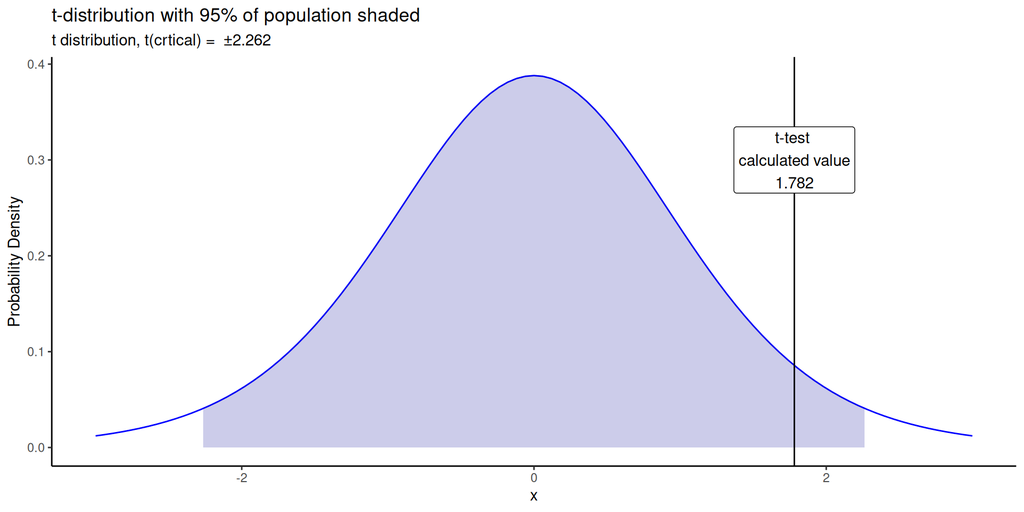

```r
tibble(x = c(-3, 3)) |>
  ggplot() +
  stat_function(mapping = aes(x = x),
                fun = dt,
                args = list(df = 9),
                color = "blue") +
  stat_function(mapping = aes(x = x),
                fun = dt,
                args = list(df = 9),
                xlim = c(-2.262, 2.262),
                geom = "area",
                fill = "#000099", alpha = 0.2) +
  geom_vline(xintercept = t_test, color = "black") +
  annotate("label", x = t_test, y = 0.3, label = paste0("t-test \ncalculated value\n", round(t_test, 3)), color = "black") +
  labs(
    title = "t-distribution with 95% of population shaded",
    subtitle = "t distribution, t(crtical) =  ±2.262",
    y = "Probability Density"
  ) +
  theme_classic()
```

## Statistical Test: Example 2

### Do two processes have the same mean? ([7.3.1](https://www.itl.nist.gov/div898/handbook/prc/section3/prc31.htm))

Setup the null and alternative hypothesis.

$$\begin{aligned}
H_0 & : \mu_1 = \mu_2 \\
H_a & : \mu_1 \neq \mu_2
\end{aligned}$$

For a one-sided test

$$\begin{aligned}
H_0 & : \mu_1 \le \mu_2 \\
H_a & : \mu_1 > \mu_2 \\
\textrm{or} \\
H_0 & : \mu_1 \ge \mu_2 \\
H_a & : \mu_1 < \mu_2
\end{aligned}$$

## What dow we know?

### Means

$$\overline{Y1} = \frac{1}{n_1} \sum_{i=1}^{n_1} Y1_i \, , \,\,\,\,\,
\overline{Y2} = \frac{1}{n_2} \sum_{i=1}^{n_2} Y2_i$$

### Standard Deviations

$$s_1 = \sqrt{\frac{1}{n_1-1} \sum_{i=1}^{n_1} (Y1_i - \overline{Y1})^2} \, , \,\,\,\,\,
s_2 = \sqrt{\frac{1}{n_2-1} \sum_{i=1}^{n_2} (Y2_i - \overline{Y2})^2}$$

The type of t-test used will depend on whether the variances are equal or not.

## t-test for Equal and Unequal Variances

### Equal Variances

$$t = \frac{\overline{Y1} - \overline{Y2}}{s_p \sqrt{\frac{1}{n_1} + \frac{1}{n_2}}}$$

where

$$s_p = \sqrt{\frac{(n_1 - 1)s_1^2 + (n_2 - 1)s_2^2}{n_1 + n_2 - 2}}$$

### Unequal Variances

$$t = \frac{\overline{Y1} - \overline{Y2}}{\sqrt{\frac{s_1^2}{n_1} + \frac{s_2^2}{n_2}}}$$

In this case, the degrees of freedom are not known exactly but can be estimated using the Welch-Satterthwaite equation.

$$\nu = \frac{\left( \frac{s_1^2}{N_1} + \frac{s_2^2}{N_2} \right)^2}
{\frac{s_1^4}{N_1^2(N_1-1)} + \frac{s_2^4}{N_2^2(N_2-1)}}$$

## We’re going to use the

`t.test()`

function from the *stats* package in R.

?t.test

## From the help file

### Usage

```r
t.test(x, ...)

## Default S3 method:
t.test(x, y = NULL,
       alternative = c("two.sided", "less", "greater"),
       mu = 0, paired = FALSE, var.equal = FALSE,
       conf.level = 0.95, ...)
```

## Statistical Test: Example 2 (1/5)

### Data [(7.3.1)](https://www.itl.nist.gov/div898/handbook/prc/section3/prc31.htm)

| Device | Process 1 (Old) | Process 2 (New) |
| --- | --- | --- |
| 1 | 32 | 36 |
| 2 | 37 | 31 |
| 3 | 35 | 30 |
| 4 | 28 | 31 |
| 5 | 41 | 34 |
| 6 | 44 | 36 |
| 7 | 35 | 29 |
| 8 | 31 | 32 |
| 9 | 34 | 31 |
| 10 | 38 |  |
| 11 | 42 |  |

### Data Frame

```r
process_df <- tibble(
  Device = 1:11,
  Process_1_Old = c(32, 37, 35, 28, 41, 44, 35, 31, 34, 38, 42),
  Process_2_New = c(36, 31, 30, 31, 34, 36, 29, 32, 31, NA, NA)
)

process_df
```

| Device | Process_1_Old | Process_2_New |
| --- | --- | --- |
| 1 | 32 | 36 |
| 2 | 37 | 31 |
| 3 | 35 | 30 |
| 4 | 28 | 31 |
| 5 | 41 | 34 |
| 6 | 44 | 36 |
| 7 | 35 | 29 |
| 8 | 31 | 32 |
| 9 | 34 | 31 |
| 10 | 38 | NA |

[output cut: 1 more lines]

## Statistical Test: Example 2 (2/5)

### Assume equal variance

```r
t.test(process_df$Process_2_New, process_df$Process_1_Old,
       var.equal = TRUE,
       altenrative = "less")
```

```
    Two Sample t-test

data:  process_df$Process_2_New and process_df$Process_1_Old
t = -2.1353, df = 18, p-value = 0.04673
alternative hypothesis: true difference in means is not equal to 0
95 percent confidence interval:
 -7.67502857 -0.06234517
sample estimates:
mean of x mean of y
 32.22222  36.09091
```

## Statistical Test: Example 2 (3/5)

### Summary statistics

```r
# Using C-style String Formatting Commands (see ?sprintf)

# "Process 1 (Old)"
sprintf("Process 1 (Old) Mean: %.2f", mean(process_df$Process_1_Old, na.rm = TRUE))
```

```
[1] "Process 1 (Old) Mean: 36.09"
```

```r
sprintf("Process 1 (Old) Standard Deviation: %.2f", sd(process_df$Process_1_Old, na.rm = TRUE))
```

```
[1] "Process 1 (Old) Standard Deviation: 4.91"
```

```r
# "Process 2 (New)")
sprintf("Process 2 (New) Mean: %.2f", mean(process_df$Process_2_New, na.rm = TRUE))
```

```
[1] "Process 2 (New) Mean: 32.22"
```

```r
sprintf("Process 2 (New) Standard Deviation: %.2f", sd(process_df$Process_2_New, na.rm = TRUE))
```

```
[1] "Process 2 (New) Standard Deviation: 2.54"
```

### My preferred way

```r
process_summary_df <- process_df |>
  pivot_longer(cols = c(Process_1_Old, Process_2_New),
               names_to = "Process", values_to = "Time") |>
  group_by(Process) |>
  summarise(
    mean = mean(Time, na.rm = TRUE),
    sd = sd(Time, na.rm = TRUE)) |>
  ungroup()

process_summary_df
```

| Process | mean | sd |
| --- | --- | --- |
| Process_1_Old | 36.09091 | 4.908249 |
| Process_2_New | 32.22222 | 2.538591 |

### Was our assumption of equal variance correct?

## Do two processess have the same standard deviation? [(7.3.2)](https://www.itl.nist.gov/div898/handbook/prc/section3/prc32.htm)

### State the null and alternative hypothesis

$$\begin{aligned}
H_0 & : \sigma_1 = \sigma_2 \\
H_a & : \sigma_1 \neq \sigma_2
\end{aligned}$$

or for a one side test

$$\begin{aligned}
H_0 & : \sigma_1 \le \sigma_2 \\
H_a & : \sigma_1 > \sigma_2
\end{aligned}$$

For our case, we can state the null hypothesis as

$$H_0 : \sigma_{new} \ge \sigma_{old} \\
H_a : \sigma_{new} < \sigma_{old}$$

## Statistical Test: Example 2 (4/5)

### The F-test for equality of variances

```r
var.test(process_df$Process_2_New, process_df$Process_1_Old,
         alternative = "less",
         conf.level = 0.95)
```

```
    F test to compare two variances

data:  process_df$Process_2_New and process_df$Process_1_Old
F = 0.26751, num df = 8, denom df = 10, p-value = 0.03705
alternative hypothesis: true ratio of variances is less than 1
95 percent confidence interval:
 0.0000000 0.8953837
sample estimates:
ratio of variances
         0.2675052
```

## Statistical Test: Example 2 (5/5)

### Rerun the t.test with the assumption of unequal variances

```r
t.test(process_df$Process_2_New, process_df$Process_1_Old,
       var.equal = FALSE,
       altenrative = "less")
```

```
    Welch Two Sample t-test

data:  process_df$Process_2_New and process_df$Process_1_Old
t = -2.2694, df = 15.533, p-value = 0.03788
alternative hypothesis: true difference in means is not equal to 0
95 percent confidence interval:
 -7.4914303 -0.2459435
sample estimates:
mean of x mean of y
 32.22222  36.09091
```

## Statistical Test: Example 3 (1/8)

## Comparisons based on data from more that two processes: Are the means equal? [(7.4.3)](https://www.itl.nist.gov/div898/handbook/prc/section4/prc43.htm)

### Introduction to ANOVA

> . . . study the effect of temperature on a passive component such as a resistor. We select three different temperatures and observe their effect on the resistors. This experiment can be conducted by measuring all the participating resistors before placing resistors each in three different ovens.

> Each oven is heated to a selected temperature. Then we measure the resistors again after, say, 24 hours and analyze the responses, which are the differences between before and after being subjected to the temperatures.

> The temperature is called a factor. The different temperature settings are called levels. In this example there are three levels or settings of the factor Temperature.

## Statistical Test: Example 3 (2/8)

## What is a factor?

> A factor is an independent treatment variable whose settings (values) are controlled and varied by the experimenter. The intensity setting of a factor is the level.

> Levels may be quantitative numbers or, in many cases, simply “present” or “not present” (“0” or “1”).

In this experiment, there is only one factor, temperature, and the analysis is called a one-way or one-factor ANOVA.

## Statistical Test: Example 3 (3/8)

### Hypotheses that can be tested in an ANOVA

For the one-way ANOVA, the null hypothesis is that all the population means are equal; the alternative hypothesis is that at least one population mean is different from the others.

$$\begin{aligned}
H_0 & : \mu_1 = \mu_2 = \ldots = \mu_k \\
H_a & : \textrm{at least one } \mu_i \textrm{ is different}
\end{aligned}$$

where $k$ is the number of levels of the factor.

## Statistical Test: Example 3 (4/8)

### One-way ANOVA decomposition of the total sums of squares

$$\begin{array}{ccccc}
SS(Total) & = & SST & + & SSE \\
& & & & \\
\sum_{i=1}^k \sum_{j=1}^{n_i} (y_{ij} - \bar{y}_{\huge{\cdot \cdot}})^2 & = &
\sum_{i=1}^k n_i (\bar{y}_{i \huge{\cdot}} - \bar{y}_{\huge{\cdot \cdot}})^2 & + &
\sum_{i=1}^k \sum_{j=1}^{n_i} (y_{ij} - \bar{y}_{i \huge{\cdot}})^2
\end{array}$$

where $k$ is the number of *treatments* and $n_i$ is the number of observations in the $i$th treatment.

- SS(Total) or Total SS (total sum of squares)
- SST is the sum of squares of treatments
- SSE is the sum of squares of error

## Statistical Test: Example 3 (5/8)

### AVOVA Table

| Source of Variation | Sum of Squares | Degrees of Freedom | Mean Square | F-ratio |
| --- | --- | --- | --- | --- |
| Between Groups (SST) | SST | k - 1 | MST = SST / (k - 1) | F = MST / MSE |
| Within Groups (SSE) | SSE | N - k | MSE = SSE / (N - k) |  |
| Total (Total SS) | Total SS | N - 1 |  |  |

- SST: Sum of Squares Treatment (Between Groups)
- SSE: Sum of Squares Error (Within Groups)
- Total SS: Total Sum of Squares
- k: Number of groups
- N: Total number of observations

## Statistical Test: Example 3 (6/8)

### Data

```r
data <- tibble(
  Level_1 = c(6.9, 5.4, 5.8, 4.6, 4.0),
  Level_2 = c(8.3, 6.8, 7.8, 9.2, 6.5),
  Level_3 = c(8.0, 10.5, 8.1, 6.9, 9.3)
)

data
```

| Level_1 | Level_2 | Level_3 |
| --- | --- | --- |
| 6.9 | 8.3 | 8.0 |
| 5.4 | 6.8 | 10.5 |
| 5.8 | 7.8 | 8.1 |
| 4.6 | 9.2 | 6.9 |
| 4.0 | 6.5 | 9.3 |

### Convert the data to long format for ANOVA

```r
data_long <- data %>%
  pivot_longer(cols = everything(),
               names_to = "Level",
               values_to = "Value")

data_long
```

| Level | Value |
| --- | --- |
| Level_1 | 6.9 |
| Level_2 | 8.3 |
| Level_3 | 8.0 |
| Level_1 | 5.4 |
| Level_2 | 6.8 |
| Level_3 | 10.5 |
| Level_1 | 5.8 |
| Level_2 | 7.8 |
| Level_3 | 8.1 |
| Level_1 | 4.6 |

[output cut: 5 more lines]

## Statistical Test: Example 3 (7/8)

### ANOVA

```r
aov_results <- aov(Value ~ Level, data = data_long)

summary(aov_results)
```

```
            Df Sum Sq Mean Sq F value  Pr(>F)
Level        2  27.90  13.949   9.591 0.00325 **
Residuals   12  17.45   1.454
---
Signif. codes:  0 '***' 0.001 '**' 0.01 '*' 0.05 '.' 0.1 ' ' 1
```

### Calculate the F critical value using the F distribution

```r
alpha = 0.05
k = 3
n = 5
N = n * k

f_crit = qf(1 - alpha, df1 = k - 1, df2 = N - k)
f_crit
```

```
[1] 3.885294
```

## Statistical Test: Example 3 (8/8)

### Plot the data (which we probalby should have done first!)

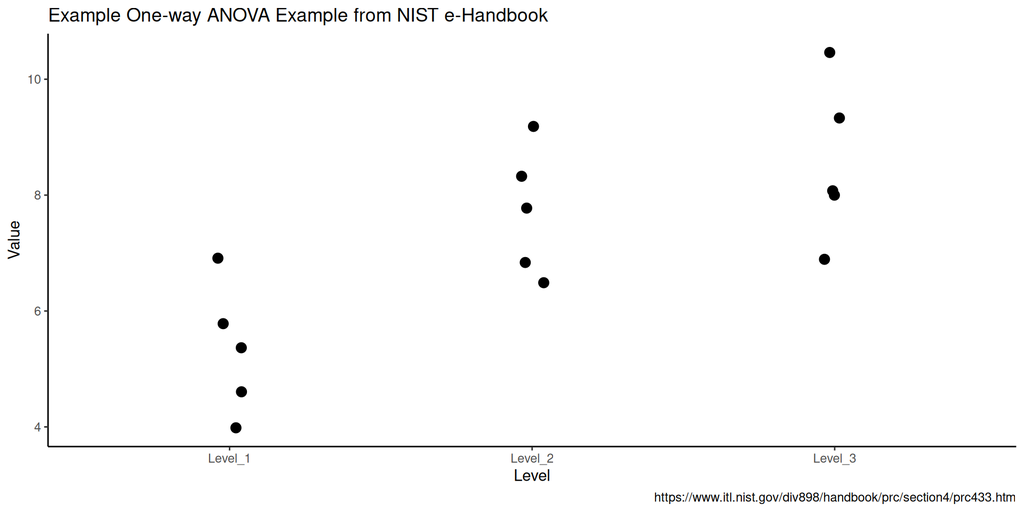

```r
data_long |>
  ggplot(aes(x = Level, y = Value)) +
  geom_point(position = position_jitter(width = 0.05), size = 3) +
  labs(
    x = "Level",
    y = "Value",
    title = "Example One-way ANOVA Example from NIST e-Handbook",
    caption = "https://www.itl.nist.gov/div898/handbook/prc/section4/prc433.htm"
  ) +
  theme_classic()
```

## Assignment

### Carry out a one-way ANOVA on the following dataset

[PSU STAT 502](https://online.stat.psu.edu/stat502/lesson/3/3.6)

```r
greenhouse_df <- tibble(
  Control = c(21, 19.5, 22.5, 21.5, 20.5, 21),
  F1 = c(32, 30.5, 25, 27.5, 28, 28.6),
  F2 = c(22.5, 26, 28, 27, 26.5, 25.2),
  F3 = c(28, 27.5, 31, 29.5, 30, 29.2)
)

greenhouse_df
```

| Control | F1 | F2 | F3 |
| --- | --- | --- | --- |
| 21.0 | 32.0 | 22.5 | 28.0 |
| 19.5 | 30.5 | 26.0 | 27.5 |
| 22.5 | 25.0 | 28.0 | 31.0 |
| 21.5 | 27.5 | 27.0 | 29.5 |
| 20.5 | 28.0 | 26.5 | 30.0 |
| 21.0 | 28.6 | 25.2 | 29.2 |

### Carry out a two-way ANOVA on the following dataset

[PSU STAT 502](https://online.stat.psu.edu/stat502/lesson/5/5.2)

```r
greenhouse_df_2 <- read_table("fert species resp
control SppA    21.0
control SppA    19.5
control SppA    22.5
control SppA    21.5
control SppA    20.5
control SppA    21.0
control SppB    23.7
control SppB    23.8
control SppB    23.8
control SppB    23.7
control SppB    22.8
control SppB    24.4
f1  SppA    32.0
f1  SppA    30.5
f1  SppA    25.0
f1  SppA    27.5
f1  SppA    28.0
f1  SppA    28.6
f1  SppB    30.1
f1  SppB    28.9
f1  SppB    30.9
f1  SppB    34.4
f1  SppB    32.7
f1  SppB    32.7
f2  SppA    22.5
f2  SppA    26.0
f2  SppA    28.0
f2  SppA    27.0
f2  SppA    26.5
f2  SppA    25.2
f2  SppB    30.6
f2  SppB    31.1
f2  SppB    28.1
f2  SppB    34.9
f2  SppB    30.1
f2  SppB    25.5
f3  SppA    28.0
f3  SppA    27.5
f3  SppA    31.0
f3  SppA    29.5
f3  SppA    30.0
f3  SppA    29.2
f3  SppB    36.1
f3  SppB    36.6
f3  SppB    38.7
f3  SppB    37.1
f3  SppB    36.8
f3  SppB    37.1
", col_names = TRUE)

greenhouse_df_2
```

| fert | species | resp |
| --- | --- | --- |
| control | SppA | 21.0 |
| control | SppA | 19.5 |
| control | SppA | 22.5 |
| control | SppA | 21.5 |
| control | SppA | 20.5 |
| control | SppA | 21.0 |
| control | SppB | 23.7 |
| control | SppB | 23.8 |
| control | SppB | 23.8 |
| control | SppB | 23.7 |

[output cut: 38 more lines]

# End of Module 5